# R Markdown Assignment, Week 2-4

Jennifer Kidson

January 15, 2016

#### Managing the working directory in R markdown

```r
# set working directory if has child directory
dir_child = 'students'
if (dir_child %in% list.files()){
  if (interactive()) {
    # R Console
    setwd(dir_child)
  } else {
    # knitting
    knitr::opts_knit$set(root.dir=dir_child)
  }
}
```

## 1. Reproducible Science Tools

For this class, the group will be working to create a program to take in survey data in real time, reorganize it, and output summary statistics. For my group project (on Santa Barbara water supply) and future work, I’m most interested in learning data management strategies and ways to visualize data.

### Techniques

1. Wrangling data
2. Cleaning up data
3. Visualizing data
   - **interactive maps**
   - *interactive time series*

### Data

A group member has data on survey responses on solid waste. Data is received via text message and associated timestamps. The responses need to be tied to a specific survey question and organized.

### Image

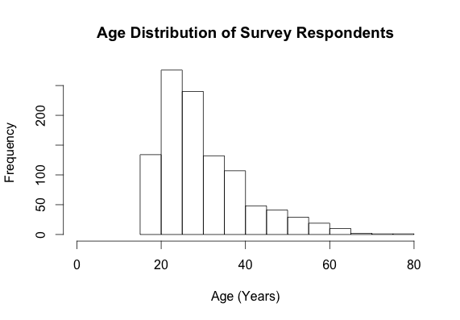

Fig. 1. Histogram of age distribution of survey respondents.

### Summary of Survey Response Data

```r
# read csv
d = read.csv('data/jkidson_ugandasms.csv')

# output summary
summary(d)
```

```
##  Nominated      Zone       years_zone        gender         age
##  no :504   ZONE I : 24   Min.   : 1.000   female:442   Min.   :18.0
##  yes:536   ZONE V : 22   1st Qu.: 2.000   male  :598   1st Qu.:23.0
##            CHURCH : 18   Median : 5.000                Median :28.0
##            LUGOBA : 15   Mean   : 9.192                Mean   :30.5
##            LUBIRI : 14   3rd Qu.:13.000                3rd Qu.:35.0
##            B 9    : 13   Max.   :65.000                Max.   :76.0
##            (Other):934
##             satis
##  dissatisfied  :320
##  neither_satisf:124
##  satisfied     :270
##  very_dissatisf:283
##  very_satisfied: 43
##
##
```

### [Citizen Monitoring Github Page](https://github.com/citizen-monitoring)

## 3. Data Wrangling

### Reading CSV with readr

```r
library(readr)

d = read_csv('data/jkidson_ugandasms.csv')
head(d)
```

```
##   Nominated      Zone years_zone gender age          satis
## 1       yes    LUGOBA          6 female  30 very_dissatisf
## 2        no  KISOWERA         30 female  40      satisfied
## 3       yes  KISOWERA         15   male  29      satisfied
## 4       yes GOOD HOPE          1 female  42 very_satisfied
## 5       yes    LUGOBA          2   male  23      satisfied
## 6        no    CORNER          3 female  30 very_dissatisf
```

```r
summary(d)
```

```
##   Nominated             Zone             years_zone        gender
##  Length:1040        Length:1040        Min.   : 1.000   Length:1040
##  Class :character   Class :character   1st Qu.: 2.000   Class :character
##  Mode  :character   Mode  :character   Median : 5.000   Mode  :character
##                                        Mean   : 9.192
##                                        3rd Qu.:13.000
##                                        Max.   :65.000
##       age          satis
##  Min.   :18.0   Length:1040
##  1st Qu.:23.0   Class :character
##  Median :28.0   Mode  :character
##  Mean   :30.5
##  3rd Qu.:35.0
##  Max.   :76.0
```

### dplyr Demo

#### Pseudocode

```r
# read in csv
# view data
# limit columns to Zone and satis
# limit rows to just zone "CORNER"
# get count for each satisfaction level
# write out csv
```

#### Multiple Variables

```r
# read in csv
surveys = read.csv('data/jkidson_ugandasms.csv')

# view data
head(surveys)
```

```
##   Nominated      Zone years_zone gender age          satis
## 1       yes    LUGOBA          6 female  30 very_dissatisf
## 2        no  KISOWERA         30 female  40      satisfied
## 3       yes  KISOWERA         15   male  29      satisfied
## 4       yes GOOD HOPE          1 female  42 very_satisfied
## 5       yes    LUGOBA          2   male  23      satisfied
## 6        no    CORNER          3 female  30 very_dissatisf
```

```r
summary(surveys)
```

```
##  Nominated      Zone       years_zone        gender         age
##  no :504   ZONE I : 24   Min.   : 1.000   female:442   Min.   :18.0
##  yes:536   ZONE V : 22   1st Qu.: 2.000   male  :598   1st Qu.:23.0
##            CHURCH : 18   Median : 5.000                Median :28.0
##            LUGOBA : 15   Mean   : 9.192                Mean   :30.5
##            LUBIRI : 14   3rd Qu.:13.000                3rd Qu.:35.0
##            B 9    : 13   Max.   :65.000                Max.   :76.0
##            (Other):934
##             satis
##  dissatisfied  :320
##  neither_satisf:124
##  satisfied     :270
##  very_dissatisf:283
##  very_satisfied: 43
##
##
```

```r
# limit columns to species and year
surveys_2 = surveys[,c('Zone', 'satis')]

# limit rows to just species "NL"
surveys_3 = surveys_2[surveys_2$Zone  == 'CORNER',]

# get count per year
surveys_4 = aggregate(Zone ~ satis, data=surveys_3, FUN='length')

# write to csv
write.csv(surveys_4, 'data/surveys_jkidson.csv', row.names = FALSE)
```

#### Nested Functions

(For some reason this nested function is giving me an error, so I commented it out for now. I’ll come back to it if I have time after the group assignment.)

```r
# read in data
surveys = read.csv('data/jkidson_ugandasms.csv')

# view data
head(surveys)
```

```
##   Nominated      Zone years_zone gender age          satis
## 1       yes    LUGOBA          6 female  30 very_dissatisf
## 2        no  KISOWERA         30 female  40      satisfied
## 3       yes  KISOWERA         15   male  29      satisfied
## 4       yes GOOD HOPE          1 female  42 very_satisfied
## 5       yes    LUGOBA          2   male  23      satisfied
## 6        no    CORNER          3 female  30 very_dissatisf
```

```r
summary(surveys)
```

```
##  Nominated      Zone       years_zone        gender         age
##  no :504   ZONE I : 24   Min.   : 1.000   female:442   Min.   :18.0
##  yes:536   ZONE V : 22   1st Qu.: 2.000   male  :598   1st Qu.:23.0
##            CHURCH : 18   Median : 5.000                Median :28.0
##            LUGOBA : 15   Mean   : 9.192                Mean   :30.5
##            LUBIRI : 14   3rd Qu.:13.000                3rd Qu.:35.0
##            B 9    : 13   Max.   :65.000                Max.   :76.0
##            (Other):934
##             satis
##  dissatisfied  :320
##  neither_satisf:124
##  satisfied     :270
##  very_dissatisf:283
##  very_satisfied: 43
##
##
```

```r
# limit data with [], aggregate to count, write to csv
# write.csv(
#  aggregate(
#    Zone ~ satis,
#    data = surveys[surveys$satis  == 'CORNER', c('Zone', 'satis')],
#    FUN = 'length'),
#  'data/surveys_jkidson.csv',
#  row.names = FALSE)
```

#### Using dplyr

```r
# load libraries
library(readr)
library(dplyr)
# read in csv
surveys = read_csv('data/jkidson_ugandasms.csv')

# dplyr elegance
surveys %T>%                            # note tee operator %T>% for glimpse
  glimpse() %>%                         # view data
  select(Zone, satis) %>%               # limit columns
  filter(Zone  == 'CORNER') %>%         # limit rows
  group_by(satis) %>%                   # get count by first grouping
  summarize(n = n()) %>%                # then summarize
  write_csv('data/surveys_jkidson.csv') # write out csv
```

```
## Observations: 1,040
## Variables: 6
## $ Nominated  (chr) "yes", "no", "yes", "yes", "yes", "no", "yes", "yes...
## $ Zone       (chr) "LUGOBA", "KISOWERA", "KISOWERA", "GOOD HOPE", "LUG...
## $ years_zone (int) 6, 30, 15, 1, 2, 3, 3, 13, 1, 2, 9, 35, 10, 4, 35, ...
## $ gender     (chr) "female", "female", "male", "female", "male", "fema...
## $ age        (int) 30, 40, 29, 42, 23, 30, 26, 32, 25, 22, 30, 35, 29,...
## $ satis      (chr) "very_dissatisf", "satisfied", "satisfied", "very_s...
```

## 4. Tidying Up Data

### EDAWR

```r
install.packages("devtools")
devtools::install_github("rstudio/EDAWR")
library(EDAWR)
help(package='EDAWR')
?storms    # wind speed data for 6 hurricanes
?cases     # subset of WHO tuberculosis
?pollution # pollution data from WHO Ambient Air Pollution, 2014
?tb        # tuberculosis data
View(storms)
View(cases)
View(pollution)
```

### slicing

```r
# storms
storms$storm
storms$wind
storms$pressure
storms$date

# cases
cases$country
names(cases)[-1]
unlist(cases[1:3, 2:4])

# pollution
pollution$city[c(1,3,5)]
pollution$amount[c(1,3,5)]
pollution$amount[c(2,4,6)]

# ratio
storms$pressure / storms$wind
```

## tidyr

Two main functions: gather() and spread()

```r
# install.packages("tidyr")
library(tidyr)
?gather # gather to long
?spread # spread to wide
```

### `gather`

```r
cases %>%
# gather(cases, "year", "n", 2:4) # gathers by key of year
# if you wanted to removed a column you could enter -2 instead of 2:4 (but this makes country weird)
gather("year", "n", -country) %>%
# France and US for 2011 and 2013
  filter(
    year %in% c(2011,2013) &
    country %in% c('FR','US'))
```

### `spread`

```r
pollution
spread(pollution, size, amount)
```

Other functions to extract and combine columns…

### `separate`

```r
storms
storms2 = separate(storms, date, c("year", "month", "day"), sep = "-")
library(stringr)
# Splitting date strings!!!
#storms%>%
#  mutate(date_str = as.character(date)) %>%
#  separate(date_str, c("year","month","day"), sep = "-")
```

### `unite`

```r
storms2
unite(storms2, "date", year, month, day, sep = "-")
```

**Recap: tidyr**:

- A package that reshapes the layout of data sets.
- Make observations from variables with `gather()` Make variables from observations with `spread()`
- Split and merge columns with `unite()` and `separate()`

### tidy CO<sub>2</sub> emissions

```r
library(readxl) # install.packages('readxl')

url = 'http://edgar.jrc.ec.europa.eu/news_docs/CO2_1970-2014_dataset_of_CO2_report_2015.xls'
xls = '../data/co2_europa.xls'

print(getwd())
```

```
## [1] "/Users/jenniferkidson/Documents/Bren Docs/296 Informatics/env-info/students"
```

```r
if (!file.exists(xls)){
  download.file(url, xls)
}
co2 = read_excel(xls, skip=12)
```

[output not shown]

```r
co2
```

```
## Source: local data frame [220 x 46]
##
##                Country  1970.000000  1971.000000  1972.000000  1973.000000
##                  (chr)        (dbl)        (dbl)        (dbl)        (dbl)
## 1          Afghanistan  1813.981234  1840.794051  1794.831482  1817.997422
## 2              Albania  4435.433037  4425.968296  5035.309230  4638.057137
## 3              Algeria 18850.745443 22226.320843 34278.432478 46375.728534
## 4       American Samoa     6.183023     6.327022     6.462429     6.587474
## 5               Angola  8946.495011  8532.101439 10382.218539 11365.512295
## 6             Anguilla     2.168006     2.168036     2.263426     2.108604
## 7  Antigua and Barbuda   196.161773   203.964395   244.721752   263.402867
## 8            Argentina 87478.401090 87827.313960 88888.066154 93076.186184
## 9              Armenia 10951.012839 10972.887313 11783.384976 12844.589903
## 10               Aruba    40.380782    40.635025    41.138578    41.949184
## ..                 ...          ...          ...          ...          ...
## Variables not shown: 1974.000000 (dbl), 1975.000000 (dbl), 1976.000000
##   (dbl), 1977.000000 (dbl), 1978.000000 (dbl), 1979.000000 (dbl),
##   1980.000000 (dbl), 1981.000000 (dbl), 1982.000000 (dbl), 1983.000000
##   (dbl), 1984.000000 (dbl), 1985.000000 (dbl), 1986.000000 (dbl),
##   1987.000000 (dbl), 1988.000000 (dbl), 1989.000000 (dbl), 1990.000000
##   (dbl), 1991.000000 (dbl), 1992.000000 (dbl), 1993.000000 (dbl),
##   1994.000000 (dbl), 1995.000000 (dbl), 1996.000000 (dbl), 1997.000000
##   (dbl), 1998.000000 (dbl), 1999.000000 (dbl), 2000.000000 (dbl),
##   2001.000000 (dbl), 2002.000000 (dbl), 2003.000000 (dbl), 2004.000000
##   (dbl), 2005.000000 (dbl), 2006.000000 (dbl), 2007.000000 (dbl),
##   2008.000000 (dbl), 2009.000000 (dbl), 2010.000000 (dbl), 2011.000000
##   (dbl), 2012.000000 (dbl), 2013.000000 (dbl), 2014.000000 (dbl)
```

**Question**. Why use `skip=12` argument in `read_excel()`? Everything before line 13 is separate from the actual data table, so skip=12 jumps over the first 12 rows.

## dplyr

A package that helps transform tabular data

```r
# install.packages("dplyr")
library(dplyr)
?select
?filter
?arrange
?mutate
?group_by
?summarise
```

See sections in the data-wrangling-cheatsheet.pdf:

- Subset Variables (Columns), eg `select()`
- Subset Observations (Rows), eg `filter()`
- Reshaping Data - Change the layout of a data set, eg `arrange()`
- Make New Variables, eg `mutate()`
- Group Data, eg `group_by()` and `summarise()`

### `select`

```r
storms
select(storms, storm, pressure)
storms %>% select(storm, pressure)
```

### `filter`

```r
storms
filter(storms, wind >= 50)
storms %>% filter(wind >= 50)

storms %>%
  filter(wind >= 50) %>%
  select(storm, pressure)
```

### `mutate`

```r
storms %>%
  mutate(ratio = pressure / wind) %>%
  select(storm, ratio)
```

### `group_by`

```r
pollution
pollution %>% group_by(city)
```

### `summarise`

```r
# by city
pollution %>%
  group_by(city) %>%
  summarise(
    mean = mean(amount),
    sum = sum(amount),
    n = n())

# by size
pollution %>%
  group_by(size) %>%
  summarise(
    mean = mean(amount),
    sum = sum(amount),
    n = n())
```

note that `summarize` synonymously works

### `ungroup`

```r
pollution %>%
  group_by(size)

pollution %>%
  group_by(size) %>%
  ungroup()
```